# Weeks 11-12

### 14.7.1.

We have $$\Delta u = \Delta v + \Delta w = f + 0 = f$$ in $\Omega$, and so it satisfies the first equation. Furthermore, $$u = v + w = v + (g-v) = g$$ on $\partial \Omega$, and so the second condition is also satisfied.

### 14.7.3.

Here's what the solution looks approximately like:

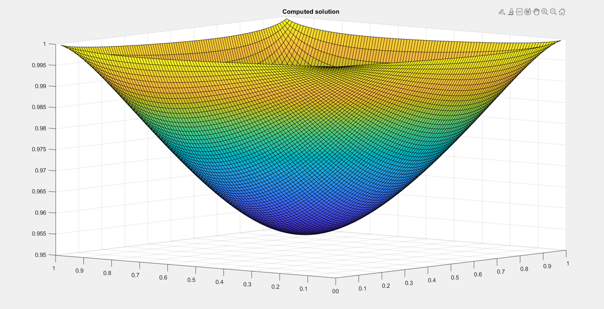

I ran it for $n$ ranging from $8$ to $49$, and used a grid with $n=64$ as the "correct" values to calculate the norm (after scaling down of course). I got the following L2 norms:

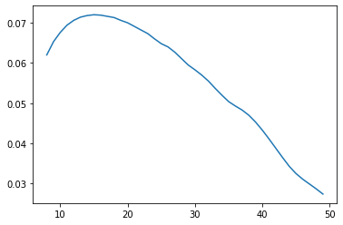

```python
%matplotlib inline
import matplotlib.pyplot as plt
import numpy as np
errors = np.array([0.0620, 0.0653, 0.0676, 0.0694, 0.0706, 0.0714, 0.0718, 0.0720, 0.0719, 0.0716, 0.0713, 0.0706, 0.0700, 0.0691, 0.0682, 0.0673, 0.0660, 0.0648, 0.0640, 0.0627, 0.0611, 0.0595, 0.0583, 0.0570, 0.0555, 0.0537, 0.0520, 0.0504, 0.0493, 0.0483, 0.0470, 0.0453, 0.0433, 0.0411, 0.0388, 0.0365, 0.0343, 0.0325, 0.0311, 0.0299, 0.0287, 0.0274])
ns = np.array(list(range(8, 50)))
plt.plot(ns, errors)
plt.show()
```

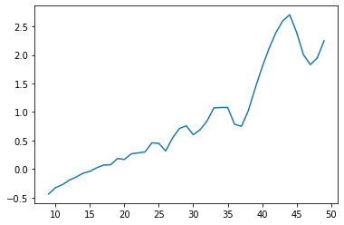

```python
log_e = np.log(errors[1:]/errors[:-1])
log_n = np.log(ns[1:]/ns[:-1])
plt.plot(ns[1:], -log_e/log_n)
```

### 14.7.4

With a mesh width of $h=0.01$ and time step of $0.00006$ the method is unstable, but it is stable when $\Delta t=0.00005$. This lines up perfectly with the inequality $$\frac{\Delta t}{h^2}\le \frac12$$ which is theoretically when stability occurs.

Code follows:

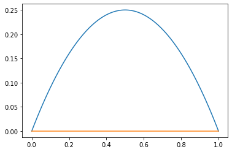

```python
t = 0
dt = 0.00005
n = 100
dx = 1/n
x = np.linspace(0, 1, n+1)
u = [(i*dx)*(1-i*dx) for i in range(n+1)]
plt.plot(x, u)
while abs(t-1) > dt/2:
    t += dt
    prev_u = u
    u = np.zeros(n+1)
    for i in range(1, n):
        u[i] = prev_u[i] + dt/dx**2 * (-2*prev_u[i] + prev_u[i+1] + prev_u[i-1])

plt.plot(x, u)
plt.show()
```

### 4.

I've been completely unable to get it to converge for any $n$. I'm sure there is something wrong with my code, but I've been stuck trying to fix it for hours!

I split it into two regions, a left and a right region. Each region contains $n$ points in the $x$ direction and $n-1$ in the $y$ direction. Both regions contain $x=0$. For some reason, I get the following diagram and it never converges!

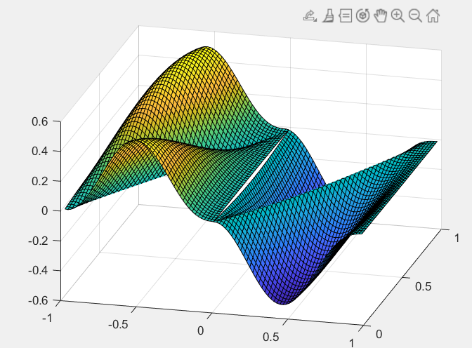

There is always a gap right at zero between the two regions, and I do not know why. When I tried solving for the whole area at once, rather than separating it into two regions, it was a very poor solution (very stiff), and that might have something to do with it. My best guess is there is no continuous solution to this problem.